# Simple Logistic Regression

## Introduction

This data table includes the infant mortality rates and GDP for most countries from 1998.  
The infant mortality rate (IMF) is the number of children who die in their first year out of every 1,000 live births.  
The GDP indicates the GDP per capita, measured in USD.

```r
datatable(un1, options=list(lengthMenu = c(3,15,45,207)))
```

|  | Country | Infant_Mortality_Rate | GDP |
| --- | --- | --- | --- |
| 1 | Afghanistan | 154 | 2848 |
| 2 | Albania | 32 | 863 |
| 3 | Algeria | 44 | 1531 |
| 4 | American Samoa | 11 |  |
| 5 | Andorra |  |  |
| 6 | Angola | 124 | 355 |
| 7 | Antigua | 24 | 6966 |
| 8 | Argentina | 22 | 8055 |
| 9 | Armenia | 25 | 354 |
| 10 | Australia | 6 | 20046 |

[output cut: 197 more lines]

**The purpose of this analysis is to determine if the GDP can be used to predict if a country has a high IMF, which will be defined as an IMF or 20 or higher.**

## Analysis

**A logistic regression has been performed here:**

$$P(Y_i = 1|\, x_i) = \frac{e^{\beta_0 + \beta_1 x_i}}{1+e^{\beta_0 + \beta_1 x_i}} = \pi_i$$

$$H_0 : \beta_0 = 0$$
$$H_0 : \beta_1 = 0$$

$$H_a : \beta_0 \ne 0$$

$$H_a : \beta_1 \ne 0$$

**In the summary table below, “(Intercept), Estimate” is the value $\beta_0$ and “GDP, Estimate” is the $\beta_1$ value:**

```r
un.glm <- glm(Infant_Mortality_Rate > 19 ~ GDP, data=un1, family=binomial)
pander(summary(un.glm))
```

|  | Estimate | Std. Error | z value | Pr(>\|z\|) |
| --- | --- | --- | --- | --- |
| **(Intercept)** | 2.071 | 0.2779 | 7.454 | 9.05e-14 |
| **GDP** | -0.0003477 | 6.14e-05 | -5.663 | 1.486e-08 |

(Dispersion parameter for binomial family taken to be 1 )

| Null deviance: | 255.0 on 192 degrees of freedom |
| --- | --- |
| Residual deviance: | 153.8 on 191 degrees of freedom |

**A Hosmer-Lemeshow Goodness of Fit Test shows that this regresion model is appropriate:**

```r
pander(hoslem.test(un.glm$y, un.glm$fitted, g=6))
```

Hosmer and Lemeshow goodness of fit (GOF) test: `un.glm$y, un.glm$fitted`

| Test statistic | df | P value |
| --- | --- | --- |
| 9.175 | 4 | 0.05687 |

**This graph shows the observed relationship:**

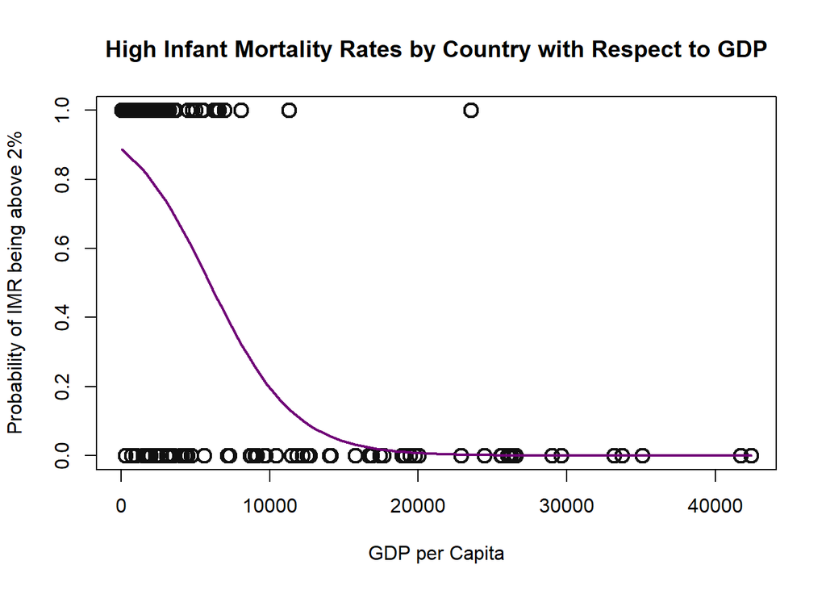

```r
plot(Infant_Mortality_Rate > 19 ~ GDP, data=un1, ylab="Probability of IMR being above 2%", main="High Infant Mortality Rates by Country with Respect to GDP", xlab="GDP per Capita", cex=1.6, lwd=2, col="#111111")
curve(exp(2.0713127-0.0003477*x)/(1+exp(2.0713127-0.0003477*x)), col="#700077", lwd=2, add=TRUE)
```

## Interpretation

**It can be concluded that countries with a lower GDP are more likely to have an infant mortality rate above 2%. This table shows the some specific levels:**

| GDP | Probability |
| --- | --- |
| 0 | 89% |
| 968 | 85% |
| 1,970 | 80% |
| 2,798 | 75% |
| **5,957** | **50%** |
| 9,117 | 25% |
| 12,276 | 10% |
| 14,426 | 5% |
| 19,173 | 1% |